# Financial consumer complaint analysis

```python
pip install -U kaleido
```

pip install -U kaleido

```
     ━━━━━━━━━━━━━━━━━━━━━━━━━━━━━━━━━━━━━━━━ 79.9/79.9 MB 13.6 MB/s eta 0:00:00
WARNING: Running pip as the 'root' user can result in broken permissions and conflicting behaviour with the system package manager. It is recommended to use a virtual environment instead: https://pip.pypa.io/warnings/venv
```

[figure not shown]

## **1 |** **BACKGROUND**

In this section we will outline what customer feedback is, why it is an important part of any business, not only for financial companies, but in general. Show some examples, which should show that it can take some time to manually read and analyse what each consumer complaint is about. How can we utilise consumer feedback to streamline the process of consumer-company interaction (the need)

### **CONSUMER FEEDBACK**

Let's point our some key points about consumer feedback:

**Consumer feedback** is an important part of day to day financial business operations Companies offering products must be able to know what their consumers think of their products Eg. positive & negative feedback & can be obtained from a number of sources (eg. twitter) In this case, we obtain data from a [**database**](https://www.consumerfinance.gov/data-research/consumer-complaints/), which registers consumers feedback of financial products Customers have specific **issue** on a number of **topics** they want want the company to address The form of consumer communication with the financial institution is via the **web** (as will be shown later)

**USEFULNESS OF CONSUMER FEEDBACK**

**Can your customers tell you something important?** | **[Source](https://www.startquestion.com/blog/7-reasons-why-customer-feedback-is-important-to-your-business/)**

> If you run your own business, I know you do your best to please your customers  
> Satisfy their needs, and keep them loyal to your brand.  
> But how can you be sure that your efforts bring desired results?  
> If you do not try to find out what your clients think about your service  
> You will never be able to give them the best customer experience.  
> **Their opinions** about their experience with your brand are helpful information  
> That you can **use to adjust your business to fit their needs more accurately**
- The source clearly outlines that consumer feedback is quite critical for any business
- **Consumer feedback** in our problem is related to a consumer having an `issue` with a particualr financial `product` or alike

**CONSUMER FEEDBACK EXAMPLES**

Let's look at a couple of examples of a consumer's addresses to a company:

Product: **Credit reporting** | Issue: **Incorrect information on credit report**

> After looking at my credit report I saw a collection account that does not belong to me. I am not allowed to dispute this information online on Experian or over the phone making it impossible for me. This false information is ruining my credit and knowing full well this people did not do their job and allow people to just post false accounts on my report. They need to delete this information immediately and do a proper investigation as this information is not mine. '

Product: **Credit card** | Issue: **Credit line increase/decrease**

> "XXXX i receive an email from citibank regarding my XXXX credit card. It was an offer to request a credit increase and it clearly stated that there would be NO Credit bureau inquiry made. I clicked on the link in the email and entered the requested information. a couple of days later I received an alert from my credit bureau monitoring service that a hard inquiry was done. Upon looking at the report it showed Citibank credit cards making a hard credit inquiry which was completely opposite of what their email stated. I called citi and they confimred that the email stated there would be no creidt inquiry done however they said that the request was made on a different citibank credit card which is why the hard inquiry was made. I explained to the rep I clicked on the link they provided and if was for a different account of mine it was not my issue but theirs and they need to remove the inquiry. They told me to send a letter to their credit dispute department explaining it. I sent the letter after waiting more than a month I received a blunt statement stating the it was a valid credit request and they will not remove the inquiry from my credit bureau. Citi performed bait and switch by offering a no inquiry credit request and then doing a hard inquiry which has negatively affected my credit score. I asked to remove it and received a generic letter stating they would not with no number to contact the department that sent the letter when i called the main customer service number they said that department dosent talk to customers and there was nothing else they can do. This has negatively affected my credit score and will remain on my credit report for 2 years because citi 's False advertising. and then their lack of fixing their error "

After reading this long complaint:

- It should become apparent that **manual evaluation** of each consumer issue can can a while to process and is very inefficient
- For a timely & helpful consumer response, the **relevant problem** not only must be processed in a timely manner, but passed on to **a specific expert that has experience dealing with the particular issue**

## **2 |** **NOTEBOOK WORKFLOW**

### **STUDY AIM**

- In this notebook, we'll be utilising **machine learning**, to create a model(s) that will be able to classify the type of complaint (as we did above) (by both **product** & **issue**)
- Such a model can be useful for a company to quickly understand the type of complaint & appoint a financial expert that will be able to solve the problem

### **AUTOMATED TICKET CLASSIFICATION MODEL**

Our approach will include **separate models**, that will be in charge of classifying data on different subsets of data

- **M1** will be classifying a **product** based on the customer's input complaint (`text`) (eg. Credit Reporting)
- **M2** will be in charge of classifying the particular **issue** to which the complaint belongs to (**text**)

## **3 |** **DATA PREPROCESSING**

In this section, we will dive in to the dataset, making some slight adjustments; loading the data, looking at missing data, looking at the features & make some slight adustments

### **CONSUMER COMPLAINT DATABASE**

- Download full [**Dataset**](https://www.consumerfinance.gov/data-research/consumer-complaints/) from the provided link if you want to have the up to date data
- Complaints that the Consumer Financial Protection Bureau (CFPB) sends to companies for response are published in the Consumer Complaint Database after the company responds
- Confirming a commercial relationship with the consumer, or after 15 days, whichever comes first

### **LOAD DATASET**

We start off by loading the dataset (we are loading the dataset without any missing data in `consumer complaint narrative` (which is the complaint)

```python
%%time
import pandas as pd
import plotly.express as px
import numpy as np
import seaborn as sns
import matplotlib.pyplot as plt

df = pd.read_csv('/kaggle/input/complaintsfull/main.csv',low_memory=False)
df = df.drop(['Unnamed: 0'],axis=1)
```

%%time import pandas as pd import plotly.express as px import numpy as np import seaborn as sns import matplotlib.pyplot as plt df = pd.read_csv('/kaggle/input/complaintsfull/main.csv',low_memory=False) df = df.drop(['Unnamed: 0'],axis=1)

```
CPU times: user 22.3 s, sys: 3.15 s, total: 25.5 s
Wall time: 36.9 s
```

### **TARGET LABELS**

A quick glimps into the dataset gives us the view of the features that will be of interest to us in this study

- **Product** (Type of financial product)
- **Sub-product** (A more detailed subset of product)
- **Issue** (What was the problem)
- **Sub-issue** (A more detailed subset of product)

### **MISSING DATA**

Visualise missing data in the dataset, looks like we have quite a bit overall & some in target variables (`Sub-Product` & `Sub-Issue`)

```python
import missingno as ms
ms.matrix(df)
```

import missingno as ms ms.matrix(df)

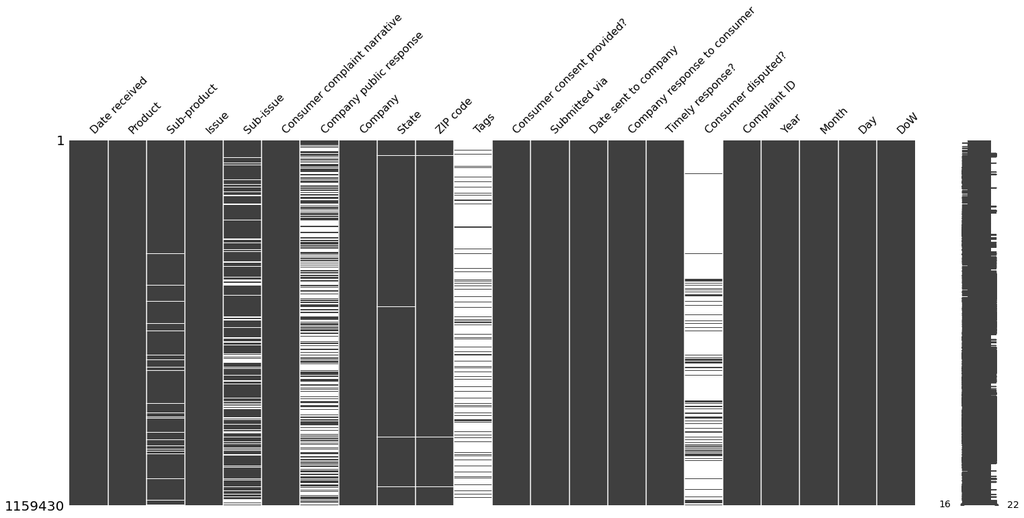

- We have quite a bit of missing data, we have already removed rows, which have missing data in our text target (consumer complaint narrative)
- And quite a heavy dataset, let's utilise only the relevant data for our problem (by the end of this section) which should reduce the number of rows in our data significatntly

### **FEATURE DESCRIPTION**

Brief summary of what each feature represents in our dataset

```python
print('Dataset Features')
df.columns
```

print('Dataset Features') df.columns

```
Dataset Features
```

```
Index(['Date received', 'Product', 'Sub-product', 'Issue', 'Sub-issue',
       'Consumer complaint narrative', 'Company public response', 'Company',
       'State', 'ZIP code', 'Tags', 'Consumer consent provided?',
       'Submitted via', 'Date sent to company', 'Company response to consumer',
       'Timely response?', 'Consumer disputed?', 'Complaint ID', 'Year',
       'Month', 'Day', 'DoW'],
      dtype='object')
```

- **Date received** - When the complaint was addressed
- **Product** - Complaint Type
- **Issue** - Brief summary of the issue
- **Consumer complaint narrative** - What the customer wrote (documents)
- **Company public response** - How did the company respond
- **State** - State in which the complaint was made
- **Submitted** - Form of complaint
- **Customer disputed?** - Did the customer dispute the response

### **ADDING DATETIME FEATURES**

Lets add time-series based features, normalise column and column subset names & remove some column subset data for our target variable

- We have two timeline features, `Date received` & `Date sent to company`
- Lets extract additional features which can be useful for EDA

```python
def object_to_datetime_features(df,column):

    df[column] = df[column].astype('datetime64[ns]')
    df['Year'] = df[column].dt.year
    df['Month'] = df[column].dt.month
    df['Day'] = df[column].dt.day
    df['DoW'] = df[column].dt.dayofweek
    df['DoW'] = df['DoW'].replace({0:'Monday',1:'Tuesday',2:'Wednesday',
                                   3:'Thursday',4:'Friday',5:'Saturday',6:'Sunday'})
    return df

df = object_to_datetime_features(df,'Date received')
df.columns
```

def object_to_datetime_features(df,column): df[column] = df[column].astype('datetime64[ns]') df['Year'] = df[column].dt.year df['Month'] = df[column].dt.month df['Day'] = df[column].dt.day df['DoW'] = df[column].dt.dayofweek df['DoW'] = df['DoW'].replace({0:'Monday',1:'Tuesday',2:'Wednesday', 3:'Thursday',4:'Friday',5:'Saturday',6:'Sunday'}) return df df = object_to_datetime_features(df,'Date received') df.columns

```
Index(['Date received', 'Product', 'Sub-product', 'Issue', 'Sub-issue',
       'Consumer complaint narrative', 'Company public response', 'Company',
       'State', 'ZIP code', 'Tags', 'Consumer consent provided?',
       'Submitted via', 'Date sent to company', 'Company response to consumer',
       'Timely response?', 'Consumer disputed?', 'Complaint ID', 'Year',
       'Month', 'Day', 'DoW'],
      dtype='object')
```

### **COLUMN NAME NORMALISATION**

Lets convert all column names to a lower register

```python
# lower the register of columns

def normalise_column_names(df):

    normalised_features = [i.lower() for i in list(df.columns)]
    df.columns = normalised_features
    return df

df = normalise_column_names(df)
```

# lower the register of columns def normalise_column_names(df): normalised_features = [i.lower() for i in list(df.columns)] df.columns = normalised_features return df df = normalise_column_names(df)

### **NORMALISATION OF SUBSET NAMES**

Lets convert all subset feature names into a lower register as well

```python
# show the names of each subset

def show_subset_names(df,column):
    return df[column].value_counts().index

show_subset_names(df,'product')
```

# show the names of each subset def show_subset_names(df,column): return df[column].value_counts().index show_subset_names(df,'product')

```
Index(['Credit reporting, credit repair services, or other personal consumer reports',
       'Debt collection', 'Mortgage', 'Credit card or prepaid card',
       'Checking or savings account', 'Student loan', 'Credit reporting',
       'Money transfer, virtual currency, or money service',
       'Vehicle loan or lease', 'Credit card', 'Bank account or service',
       'Payday loan, title loan, or personal loan', 'Consumer Loan',
       'Payday loan', 'Money transfers', 'Prepaid card',
       'Other financial service', 'Virtual currency'],
      dtype='object')
```

```python
def normalise_subset_names(df,column):
    subset_names = list(df[column].value_counts().index)
    norm_subset_names = [i.lower() for i in subset_names]
    dict_replace = dict(zip(subset_names,norm_subset_names))
    df[column] = df[column].replace(dict_replace)
    return df

df = normalise_subset_names(df,'product')
show_subset_names(df,'product')
```

def normalise_subset_names(df,column): subset_names = list(df[column].value_counts().index) norm_subset_names = [i.lower() for i in subset_names] dict_replace = dict(zip(subset_names,norm_subset_names)) df[column] = df[column].replace(dict_replace) return df df = normalise_subset_names(df,'product') show_subset_names(df,'product')

```
Index(['credit reporting, credit repair services, or other personal consumer reports',
       'debt collection', 'mortgage', 'credit card or prepaid card',
       'checking or savings account', 'student loan', 'credit reporting',
       'money transfer, virtual currency, or money service',
       'vehicle loan or lease', 'credit card', 'bank account or service',
       'payday loan, title loan, or personal loan', 'consumer loan',
       'payday loan', 'money transfers', 'prepaid card',
       'other financial service', 'virtual currency'],
      dtype='object')
```

### **FILTER SUBSET DATA**

Let's keep only specific subsets of data in the **product** column

```python
# keep only specific subset in a feature

def keep_subset(df,column,lst):

    all_features = list(df[column].value_counts().index)
    keep_features = lst

    # subset data
    subset_data = dict(tuple(df.groupby(column)))
    subset_data_filter = lambda x, y: dict([ (i,x[i]) for i in x if i in set(y) ])

    # dictionary with only selected keys
    filtered_data = subset_data_filter(subset_data,lst)
    filtered_df = pd.concat(filtered_data.values())
    filtered_df.reset_index(drop=True,inplace=True)
    return filtered_df

# remove specific subset from feature

def remove_subset(df,column,lst):

    all_features = list(df[column].value_counts().index)
    keep_features = lst

    # subset data
    subset_data = dict(tuple(df.groupby(column)))
    set_all_features = set(all_features)
    set_keep_features = set(lst)

    # features of dictionary which should remain
    remaining_features = set_all_features - set_keep_features

    subset_data_filter = lambda x, y: dict([ (i,x[i]) for i in x if i in set(y) ])
    filtered_data = subset_data_filter(subset_data,remaining_features)
    filtered_df = pd.concat(filtered_data.values())
    filtered_df.reset_index(drop=True,inplace=True)
    return filtered_df
```

# keep only specific subset in a feature def keep_subset(df,column,lst): all_features = list(df[column].value_counts().index) keep_features = lst # subset data subset_data = dict(tuple(df.groupby(column))) subset_data_filter = lambda x, y: dict([ (i,x[i]) for i in x if i in set(y) ]) # dictionary with only selected keys filtered_data = subset_data_filter(subset_data,lst) filtered_df = pd.concat(filtered_data.values()) filtered_df.reset_index(drop=True,inplace=True) return filtered_df # remove specific subset from feature def remove_subset(df,column,lst): all_features = list(df[column].value_counts().index) keep_features = lst # subset data subset_data = dict(tuple(df.groupby(column))) set_all_features = set(all_features) set_keep_features = set(lst) # features of dictionary which should remain remaining_features = set_all_features - set_keep_features subset_data_filter = lambda x, y: dict([ (i,x[i]) for i in x if i in set(y) ]) filtered_data = subset_data_filter(subset_data,remaining_features) filtered_df = pd.concat(filtered_data.values()) filtered_df.reset_index(drop=True,inplace=True) return filtered_df

```python
lst_keep = ['credit reporting', 'debt collection', 'mortgage', 'credit card',
            'bank account or service', 'consumer Loan', 'student loan',
            'payday loan', 'prepaid card', 'money transfers',
            'other financial service', 'virtual currency']

df = keep_subset(df,'product',lst_keep)
# sdf = remove_subset(df,'product',lst_remove)
df['product'].value_counts()
```

lst_keep = ['credit reporting', 'debt collection', 'mortgage', 'credit card', 'bank account or service', 'consumer Loan', 'student loan', 'payday loan', 'prepaid card', 'money transfers', 'other financial service', 'virtual currency'] df = keep_subset(df,'product',lst_keep) # sdf = remove_subset(df,'product',lst_remove) df['product'].value_counts()

```
debt collection            195373
mortgage                    99141
student loan                33606
credit reporting            31587
credit card                 18838
bank account or service     14885
payday loan                  1746
money transfers              1497
prepaid card                 1450
other financial service       292
virtual currency               16
Name: product, dtype: int64
```

### **SELECT SUBSET OF DATA**

- Let's choose only a specific subset of time series data because to reduce the computational load
- We can note that data beyond 2017 has only three of the available subsets

```python
df['year'].value_counts()
```

df['year'].value_counts()

```
2016    73146
2017    59087
2015    51779
2021    50757
2022    42867
2018    41708
2020    40801
2019    38286
Name: year, dtype: int64
```

```python
ldf = df.groupby('product').count()['day'].to_frame().sort_values(ascending=False,by='day')

ldf.style\
    .bar(align='mid',
         color=['#d65f5f','#F1A424'])
```

ldf = df.groupby('product').count()['day'].to_frame().sort_values(ascending=False,by='day') ldf.style\ .bar(align='mid', color=['#d65f5f','#F1A424'])

| product | day |
| --- | --- |
| debt collection | 195373 |
| mortgage | 99141 |
| student loan | 33606 |
| credit reporting | 31587 |
| credit card | 18838 |
| bank account or service | 14885 |
| payday loan | 1746 |
| money transfers | 1497 |
| prepaid card | 1450 |
| other financial service | 292 |
| virtual currency | 16 |

We still have 184 thousand samples to go by, which should still be sufficient for our task

```python
df = df[df['year'].isin([2015,2016,2017])]
print(f'final shape: {df.shape}')
```

df = df[df['year'].isin([2015,2016,2017])] print(f'final shape: {df.shape}')

```
final shape: (184012, 22)
```

## **4 |** **TARGET DISTRIBUTION**

The **target variable** in our problem:

- Product Value Distribution (target variable for **M1**)

### **PRODUCT**

Let's plot the grouped subset distribution for feature `Product`

```python
fig = px.bar((df['product']
              .value_counts(ascending=False)
              .to_frame()),
             x='product',
             template='plotly_white',
             title='Product Subset Distribution')

fig.update_traces(marker_line_color='#F1A424',
                  marker_line_width=0.1,
                  marker={'color':'#F1A424'},width=0.5)

fig.show("png")
```

fig = px.bar((df['product'] .value_counts(ascending=False) .to_frame()), x='product', template='plotly_white', title='Product Subset Distribution') fig.update_traces(marker_line_color='#F1A424', marker_line_width=0.1, marker={'color':'#F1A424'},width=0.5) fig.show("png")

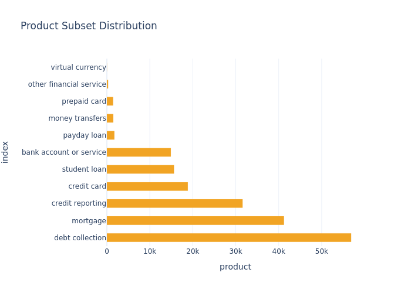

- We can note that we have some target class inbalance, in both product and issue features,
- Lets stick **stratification**, we need to make sure each class is represented in both datasets

## **5 |** **EXPLORATORY DATA ANALYSIS**

The dataset contains a lot of **categorical** which can be grouped & analysed:

- Consumer Complaint Method (How was the complaint made?)
- Company to which the consumer complained (To which company was the complaint made)
- Consumer Complaint Timeline (When were the complaints made?)
- Consumer Complaint Timeline Group Trends (grouping data; are there any trends in the timeline)
- Consumer Address State (In which state was the complaint made?)
- Company Response to Consumer Complaints (What was the response to the complaint?)
- Consumer Response to company response (Did the consumer dispuse the response?)

### **CONSUMER COMPLAINT METHOD**

- All customers addresses for which we have text data are submitted via the **web**
- This implies that all other forms of text data of complaints were not registered in the data for other forms of complaint submission

```python
df['submitted via'].value_counts(ascending=True)
```

df['submitted via'].value_counts(ascending=True)

```
Web    184012
Name: submitted via, dtype: int64
```

### **FINANCIAL COMPANY**

Let's visualise the top 10 companies for which we have consumer complaint feedback

```python
# plot subset value counts

def plot_subset_counts(df,column,orient='h',top=None):

    ldf = df[column].value_counts(ascending=False).to_frame()
    ldf.columns = ['values']

    if(top):
        ldf = ldf[:top]

    if(orient is 'h'):
        fig = px.bar(data_frame=ldf,
                     x = ldf.index,
                     y = 'values',
                     template='plotly_white',
                     title='Subset Value-Counts')

    elif('v'):

        fig = px.bar(data_frame=ldf,
                             y = ldf.index,
                             x = 'values',
                             template='plotly_white',
                             title='Subset Value-Counts')

    fig.update_layout(height=400)
    fig.update_traces(marker_line_color='white',
                      marker_line_width=0.5,
                      marker={'color':'#F1A424'},
                      width=0.75)

    fig.show("png")
```

# plot subset value counts def plot_subset_counts(df,column,orient='h',top=None): ldf = df[column].value_counts(ascending=False).to_frame() ldf.columns = ['values'] if(top): ldf = ldf[:top] if(orient is 'h'): fig = px.bar(data_frame=ldf, x = ldf.index, y = 'values', template='plotly_white', title='Subset Value-Counts') elif('v'): fig = px.bar(data_frame=ldf, y = ldf.index, x = 'values', template='plotly_white', title='Subset Value-Counts') fig.update_layout(height=400) fig.update_traces(marker_line_color='white', marker_line_width=0.5, marker={'color':'#F1A424'}, width=0.75) fig.show("png")

```python
plot_subset_counts(df,'company',orient='v',top=10)
```

plot_subset_counts(df,'company',orient='v',top=10)

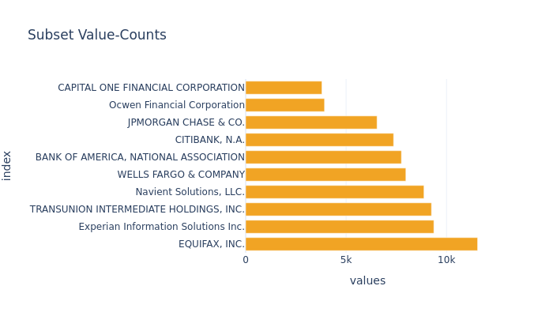

### **COMPANY RESPONSE**

Let's look at the data about what the company decided to do about the registered complaint

```python
ldf = df['company public response'].value_counts(ascending=False).to_frame()

ldf.style\
    .bar(align='mid',
         color=['#3b3745','#F1A424'])
```

ldf = df['company public response'].value_counts(ascending=False).to_frame() ldf.style\ .bar(align='mid', color=['#3b3745','#F1A424'])

|  | company public response |
| --- | --- |
| Company has responded to the consumer and the CFPB and chooses not to provide a public response | 41598 |
| Company chooses not to provide a public response | 18935 |
| Company believes it acted appropriately as authorized by contract or law | 17907 |
| Company believes the complaint is the result of a misunderstanding | 1839 |
| Company disputes the facts presented in the complaint | 1792 |
| Company believes complaint caused principally by actions of third party outside the control or direction of the company | 1436 |
| Company believes complaint is the result of an isolated error | 1345 |
| Company believes complaint represents an opportunity for improvement to better serve consumers | 813 |
| Company can't verify or dispute the facts in the complaint | 768 |
| Company believes complaint relates to a discontinued policy or procedure | 18 |

- Most of the consumer complaints were addressed in private as opposed to public

### **COMPLAINT TIMELINE**

- Let's look at the **weekly** (using `resample`) complaint addresses (let's see if there are some trends in the time series data)

```python
# Daily Complaints
complaints = df.copy()
complaints_daily = complaints.groupby(['date received']).agg("count")[["product"]] # daily addresses

# Sample weekly
complaints_weekly = complaints_daily.reset_index()
complaints_weekly = complaints_weekly.resample('W', on='date received').sum() # weekly addresses

fig = px.line(complaints_weekly,complaints_weekly.index,y="product",
              template="plotly_white",title="Weekly Complaints",height=400)
fig.update_traces(line_color='#F1A424')
fig.show("png")
```

# Daily Complaints complaints = df.copy() complaints_daily = complaints.groupby(['date received']).agg("count")[["product"]] # daily addresses # Sample weekly complaints_weekly = complaints_daily.reset_index() complaints_weekly = complaints_weekly.resample('W', on='date received').sum() # weekly addresses fig = px.line(complaints_weekly,complaints_weekly.index,y="product", template="plotly_white",title="Weekly Complaints",height=400) fig.update_traces(line_color='#F1A424') fig.show("png")

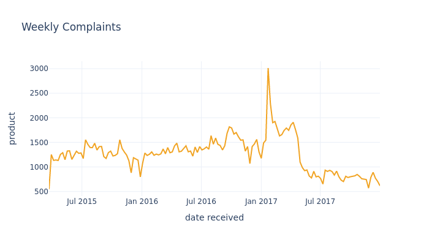

### **CONSUMER COMPLAINT TIMELINE TRENDS**

Let's group all complaint data into groups for **Day of the month** (DoM), **time of the year** (ToY) & **day of the week** (DoW)

```python
fig = px.bar(df['day'].value_counts(ascending=True).to_frame(),y='day',
             template='plotly_white',height=300,
             title='Day of the Month Complaint Trends')
fig.update_xaxes(tickvals = [i for i in range(0,32,1)])
fig.update_traces(marker_line_color='#F1A424',marker_line_width=0.1,
                  marker={'color':'#F1A424'},width=0.5)
fig.update_traces(textfont_size=12, textangle=0,
                  textposition="outside", cliponaxis=False)
fig.show("png")
```

fig = px.bar(df['day'].value_counts(ascending=True).to_frame(),y='day', template='plotly_white',height=300, title='Day of the Month Complaint Trends') fig.update_xaxes(tickvals = [i for i in range(0,32,1)]) fig.update_traces(marker_line_color='#F1A424',marker_line_width=0.1, marker={'color':'#F1A424'},width=0.5) fig.update_traces(textfont_size=12, textangle=0, textposition="outside", cliponaxis=False) fig.show("png")

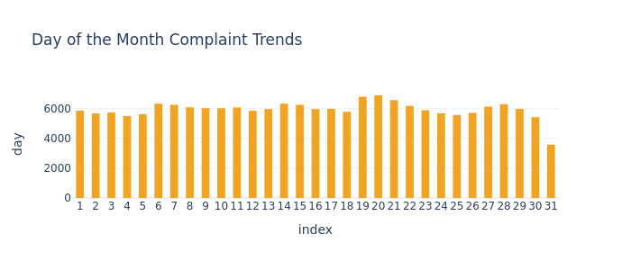

```python
fig = px.bar(df['month'].value_counts(ascending=False).to_frame(),y='month',
             template='plotly_white',height=300,
             title='Month of the Year Complaint Trends')
fig.update_xaxes(tickvals = [i for i in range(0,13,1)])
fig.update_traces(marker_line_color='#F1A424',marker_line_width=0.1,
                  marker={'color':'#F1A424'},width=0.5)
fig.show("png")
```

fig = px.bar(df['month'].value_counts(ascending=False).to_frame(),y='month', template='plotly_white',height=300, title='Month of the Year Complaint Trends') fig.update_xaxes(tickvals = [i for i in range(0,13,1)]) fig.update_traces(marker_line_color='#F1A424',marker_line_width=0.1, marker={'color':'#F1A424'},width=0.5) fig.show("png")

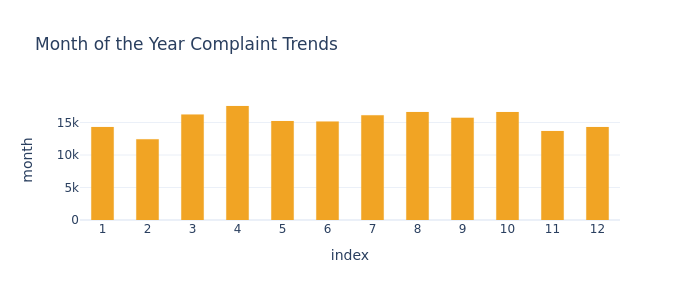

```python
# By DoW
fig = px.bar(df['dow'].value_counts(ascending=False).to_frame(),y='dow',
             template='plotly_white',height=300,
             title='Day of the Week Complaint Trends')
fig.update_traces(marker_line_color='#F1A424',marker_line_width=0.1,
                  marker={'color':'#F1A424'},width=0.5)
fig.update_traces(textfont_size=12, textangle=0, textposition="outside", cliponaxis=False)
fig.show("png")
```

# By DoW fig = px.bar(df['dow'].value_counts(ascending=False).to_frame(),y='dow', template='plotly_white',height=300, title='Day of the Week Complaint Trends') fig.update_traces(marker_line_color='#F1A424',marker_line_width=0.1, marker={'color':'#F1A424'},width=0.5) fig.update_traces(textfont_size=12, textangle=0, textposition="outside", cliponaxis=False) fig.show("png")

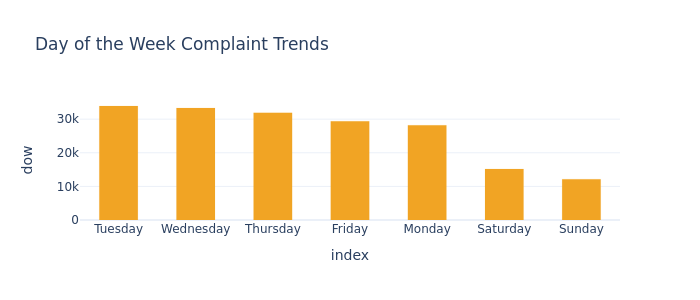

### **COMPLAINT ORIGIN (STATE)**

Let's investigate the distribution from which geographical state the complaint was made from

```python
ldf = df['state'].value_counts(ascending=True).to_frame()[50:]

fig = px.bar(ldf,x='state',template='plotly_white',
       title='State of Complaint',height=400)

fig.update_traces(marker_line_color='#F1A424',marker_line_width=1,
                  marker={'color':'#F1A424'},width=0.4)
fig.show("png")
```

ldf = df['state'].value_counts(ascending=True).to_frame()[50:] fig = px.bar(ldf,x='state',template='plotly_white', title='State of Complaint',height=400) fig.update_traces(marker_line_color='#F1A424',marker_line_width=1, marker={'color':'#F1A424'},width=0.4) fig.show("png")

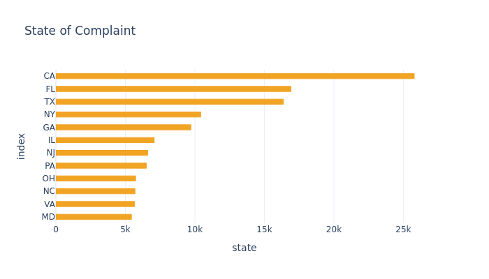

- Most of the consumer complaints are from California, Florida, Texas, Georgia and New York

### **COMPARING RESPONSE TO DISPUTES**

Lastly, we can combine the last two sections and see for each `Product`, how many disputes there have been each month

```python
disputed = df[['product','consumer disputed?','month']]

fig = px.histogram(disputed, y='product',
                   color='consumer disputed?',
                   template='plotly_white',
                   height = 700,
                   barmode='group',
                   color_discrete_sequence=['#F1A424','#3b3745'],
                   facet_col_wrap=3,
                   facet_col='month')

fig.update_layout(showlegend=False)
fig.update_layout(barmode="overlay")
fig.update_traces(opacity=0.5)
fig.show("png")
```

disputed = df[['product','consumer disputed?','month']] fig = px.histogram(disputed, y='product', color='consumer disputed?', template='plotly_white', height = 700, barmode='group', color_discrete_sequence=['#F1A424','#3b3745'], facet_col_wrap=3, facet_col='month') fig.update_layout(showlegend=False) fig.update_layout(barmode="overlay") fig.update_traces(opacity=0.5) fig.show("png")

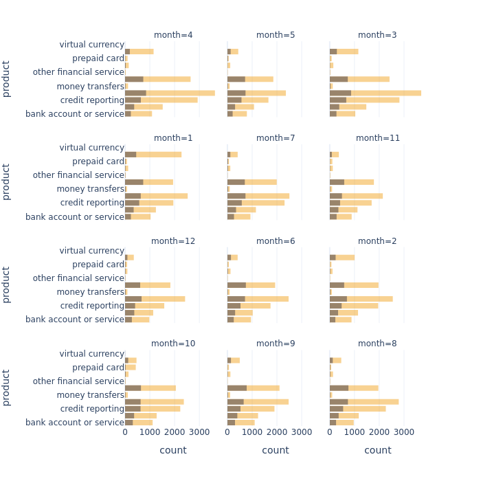

## **6 |** **PREPARING DATA FOR MODELING**

```python
df['product'].value_counts(ascending=False).to_frame().sum()
```

df['product'].value_counts(ascending=False).to_frame().sum()

```
product    184012
dtype: int64
```

```python
df['product'].value_counts(ascending=False).to_frame().tail(3)
```

df['product'].value_counts(ascending=False).to_frame().tail(3)

|  | product |
| --- | --- |
| prepaid card | 1450 |
| other financial service | 292 |
| virtual currency | 16 |

### **REVIEW CLASS DISBALANCE**

There doesn't seem to be any error associated with labelling, so let's not remove this subset

> Circle is a Boston-based financial services company that uses blockchain technology for its peer-to-peer payments and cryptocurrency-related products.

Despite wanting to utilise **Stratification**, it seems like we may not have enough data for the model to be able to classify complaints with little data available

```python
print('Sample from virtual currency:')
vc = dict(tuple(df.groupby(by='product')))['virtual currency']
vc.iloc[[0]]['consumer complaint narrative'].values[0]
```

print('Sample from virtual currency:') vc = dict(tuple(df.groupby(by='product')))['virtual currency'] vc.iloc[[0]]['consumer complaint narrative'].values[0]

```
Sample from virtual currency:
```

```
'Signedup XXXX family members for referrals on Coinbase.com. Coinbase at that time offered {$75.00} for each person referred to their service. I referred all XXXX and they met the terms Coinbase intially offered. Signup took a while do to money transfer timeframes setup by Coinbase. In that time, Co…
```

### **PRODUCT SUBSET AMBIGUITY**

- We have a feature `Credit reporting, credit repair services, or other personal consumer reports`, it seems like this feature is not quite sorted
- We already have a separate subgroup for **Credit reporting**, but not for **cedit repair services** or **other consumer reports**
- There is the possibility that this subgroup will contain complaints of other subgroups, which would affect the model accuracy
- Lets remove the subset: **Credit reporting, credit repair services, or other personal consumer reports** for the time being

Some of the approaches we could take are:

- Try to sort the data by keywords

```python
# When we have a feature that contains subsets, we can remove unwanted subsets

def remove_subset(df,feature,lst_groups):

    ndf = df.copy()

    # Let's down sample all classes with frequencies above 4k
    group = dict(tuple(ndf.groupby(by=feature)))
    subset_group = list(group.keys()) # subsets in feature

    # Check if features exist in columns
    if(set(lst_groups).issubset(subset_group)):

        # remove unwanted subset
        for k in lst_groups:
            group.pop(k, None)

        df = pd.concat(list(group.values()))
        df.reset_index(inplace=True,drop=True)

        return df
```

# When we have a feature that contains subsets, we can remove unwanted subsets def remove_subset(df,feature,lst_groups): ndf = df.copy() # Let's down sample all classes with frequencies above 4k group = dict(tuple(ndf.groupby(by=feature))) subset_group = list(group.keys()) # subsets in feature # Check if features exist in columns if(set(lst_groups).issubset(subset_group)): # remove unwanted subset for k in lst_groups: group.pop(k, None) df = pd.concat(list(group.values())) df.reset_index(inplace=True,drop=True) return df

### **LIMIT TARGET CLASS SUBSET SAMPLES**

We saw that we have quite a bit of data available

- Most of which are in particular classes (eg. credit collection ,debt reporting & mortgage)
- Let's limit our data to **4000 text samples** from each class using function `downsample_features`

```python
# Downsample selected

def downsample_subset(df,feature,lst_groups,samples=4000):

    ndf = df.copy()

    # Let's down sample all classes with frequencies above 4k
    group = dict(tuple(ndf.groupby(by=feature)))
    subset_group = list(group.keys())

    # Check if features exist in columns
    if(set(lst_groups).issubset(subset_group)):

        dict_downsamples = {}
        for feature in lst_groups:
            dict_downsamples[feature] = group[feature].sample(samples)

        # remove old data
        for k in lst_groups:
            group.pop(k, None)

        # read them back
        group.update(dict_downsamples)

        df = pd.concat(list(group.values()))
        df.reset_index(inplace=True,drop=True)

        return df

    else:
        print('feature not found in dataframe')
```

# Downsample selected def downsample_subset(df,feature,lst_groups,samples=4000): ndf = df.copy() # Let's down sample all classes with frequencies above 4k group = dict(tuple(ndf.groupby(by=feature))) subset_group = list(group.keys()) # Check if features exist in columns if(set(lst_groups).issubset(subset_group)): dict_downsamples = {} for feature in lst_groups: dict_downsamples[feature] = group[feature].sample(samples) # remove old data for k in lst_groups: group.pop(k, None) # read them back group.update(dict_downsamples) df = pd.concat(list(group.values())) df.reset_index(inplace=True,drop=True) return df else: print('feature not found in dataframe')

```python
# Select subset features which have more than 4000 samples
subset_list = list(df['product'].value_counts()[df['product'].value_counts().values > 4000].index)
df = downsample_subset(df,'product',subset_list,samples=4000)
```

# Select subset features which have more than 4000 samples subset_list = list(df['product'].value_counts()[df['product'].value_counts().values > 4000].index) df = downsample_subset(df,'product',subset_list,samples=4000)

- Let's check if our function `downsample_subset` works correctly

```python
df['product'].value_counts()
```

df['product'].value_counts()

```
debt collection            4000
mortgage                   4000
credit reporting           4000
credit card                4000
student loan               4000
bank account or service    4000
payday loan                1746
money transfers            1497
prepaid card               1450
other financial service     292
virtual currency             16
Name: product, dtype: int64
```

### **TRAIN-TEST SUBSET SPLITTING**

```python
# Select only relevant data
df_data = df[['consumer complaint narrative','product']]
df_data.columns = ['text','label']
df_data.head()
```

# Select only relevant data df_data = df[['consumer complaint narrative','product']] df_data.columns = ['text','label'] df_data.head()

|  | text | label |
| --- | --- | --- |
| 0 | I made a wire transfer through Citibank to XXX... | money transfers |
| 1 | I purchased a money order on XX/XX/2016 ( to c... | money transfers |
| 2 | I have complained of false online transfer num... | money transfers |
| 3 | I paid by bank wire transfer on XXXX/XXXX/XXXX... | money transfers |
| 4 | I found a XXXX Bulldog for sale on XXXX after ... | money transfers |

```python
from sklearn.model_selection import train_test_split as tts

train_files,test_files, train_labels, test_labels = tts(df_data['text'],
                                                        df_data['label'],
                                                        test_size=0.1,
                                                        random_state=32,
                                                        stratify=df_data['label'])

train_files = pd.DataFrame(train_files)
test_files = pd.DataFrame(test_files)
train_files['label'] = train_labels
test_files['label'] = test_labels
```

from sklearn.model_selection import train_test_split as tts train_files,test_files, train_labels, test_labels = tts(df_data['text'], df_data['label'], test_size=0.1, random_state=32, stratify=df_data['label']) train_files = pd.DataFrame(train_files) test_files = pd.DataFrame(test_files) train_files['label'] = train_labels test_files['label'] = test_labels

```python
print(type(train_files))
print('Training Data',train_files.shape)
print('Validation Data',test_files.shape)
```

print(type(train_files)) print('Training Data',train_files.shape) print('Validation Data',test_files.shape)

```
<class 'pandas.core.frame.DataFrame'>
Training Data (26100, 2)
Validation Data (2901, 2)
```

```python
import plotly.express as px

train_values = train_files['label'].value_counts()
test_values = test_files['label'].value_counts()
visual = pd.concat([train_values,test_values],axis=1)
visual = visual.T
visual.index = ['train','test']

fig = px.bar(visual,template='plotly_white',
       barmode='group',text_auto=True,height=300,
       title='Train/Test Split Distribution')

fig.show("png")
```

import plotly.express as px train_values = train_files['label'].value_counts() test_values = test_files['label'].value_counts() visual = pd.concat([train_values,test_values],axis=1) visual = visual.T visual.index = ['train','test'] fig = px.bar(visual,template='plotly_white', barmode='group',text_auto=True,height=300, title='Train/Test Split Distribution') fig.show("png")

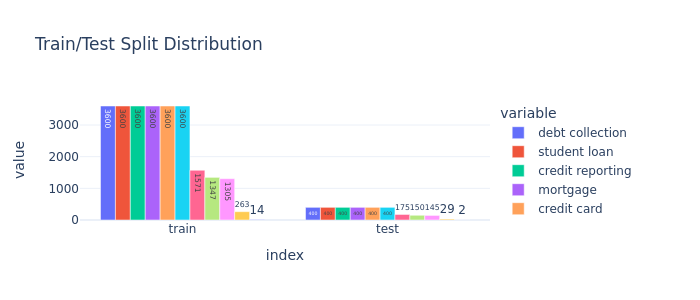

[figure not shown]

## **7 |** **LINEAR BASELINE MODEL**

In order to create a baseline model, let's extract the hidden state data from `DistilBERT` and use it as features for our linear model

### **GENERATING DATASET**

- We have a daframe containing **text** & **label** data for both training & validation datasets
- We'll use HF's more intuitive to use `Dataset` class (which allows us to convert between types very easily)

```python
train_files
```

train_files

|  | text | label |
| --- | --- | --- |
| 8290 | I paid off all of my bills and should not have... | debt collection |
| 1520 | Several checks were issued from XXXX for possi... | other financial service |
| 23071 | In XXXX, we my husband and myself took out a l... | student loan |
| 4123 | I use an Amex Serve card ( a prepaid debit car... | prepaid card |
| 16470 | Despite YEARS of stellar credit reports and sc... | credit reporting |
| ... | ... | ... |
| 21733 | I know that I am victim of student loan scam. ... | student loan |
| 27578 | On XX/XX/XXXX I made a payment of {$380.00} to... | bank account or service |
| 26297 | XXXX XXXX XXXX XXXX XXXX, AZ XXXX : ( XXXX ) X... | bank account or service |
| 17867 | After nearly a decade of business with Bank of... | credit card |
| 144 | On XXXX XXXX, 2015, I made a purchase on EBay.... | money transfers |

26100 rows × 2 columns

```python
import transformers
transformers.logging.set_verbosity_error()
import warnings; warnings.filterwarnings('ignore')
import os; os.environ['WANDB_DISABLED'] = 'true'
from datasets import Dataset,Features,Value,ClassLabel, DatasetDict

traindts = Dataset.from_pandas(train_files)
traindts = traindts.class_encode_column("label")
testdts = Dataset.from_pandas(test_files)
testdts = testdts.class_encode_column("label")
```

import transformers transformers.logging.set_verbosity_error() import warnings; warnings.filterwarnings('ignore') import os; os.environ['WANDB_DISABLED'] = 'true' from datasets import Dataset,Features,Value,ClassLabel, DatasetDict traindts = Dataset.from_pandas(train_files) traindts = traindts.class_encode_column("label") testdts = Dataset.from_pandas(test_files) testdts = testdts.class_encode_column("label")

```python
# Pandas indicies not reset ie. __index_level_0__ additional column is added, resetting index
corpus = DatasetDict({"train" : traindts ,
                      "validation" : testdts })
corpus['train']
```

# Pandas indicies not reset ie. __index_level_0__ additional column is added, resetting index corpus = DatasetDict({"train" : traindts , "validation" : testdts }) corpus['train']

```
Dataset({
    features: ['text', 'label', '__index_level_0__'],
    num_rows: 26100
})
```

### **TOKENISATION**

- Time to tokenise the **text** data
- We'll be using the `AutoTokenizer` class from a pretrained model `distilbert-base-uncased` in order to generate **subword** tokens

```python
from transformers import AutoTokenizer

# Load parameters of the tokeniser
model_ckpt = "distilbert-base-uncased"
tokenizer = AutoTokenizer.from_pretrained(model_ckpt)

# Tokenisation function
def tokenise(batch):
    return tokenizer(batch["text"],
                     padding=True,
                     truncation=True)

# apply to the entire dataset (train,test and validation dataset)
corpus_tokenised = corpus.map(tokenise,
                              batched=True,
                              batch_size=None)

print(corpus_tokenised["train"].column_names)
```

from transformers import AutoTokenizer # Load parameters of the tokeniser model_ckpt = "distilbert-base-uncased" tokenizer = AutoTokenizer.from_pretrained(model_ckpt) # Tokenisation function def tokenise(batch): return tokenizer(batch["text"], padding=True, truncation=True) # apply to the entire dataset (train,test and validation dataset) corpus_tokenised = corpus.map(tokenise, batched=True, batch_size=None) print(corpus_tokenised["train"].column_names)

```
['text', 'label', '__index_level_0__', 'input_ids', 'attention_mask']
```

### **LOADING PRESET MODEL**

HuggingFace allows us to load a variety of pretrained models:

- Let's utlilise the **distilbert-base-uncased** model

The model was trained to predict **[mask] values**

Let's use it to extract the **last hidden state** of each input sequence

- Use it to train a more tradition machine learning model (baseline **M1** model)

```python
from transformers import AutoModel
import torch

# load a pretrained transformer model
model_ckpt = "distilbert-base-uncased"
device = torch.device("cuda" if torch.cuda.is_available() else "cpu")
print(device)

# move model to device
model = AutoModel.from_pretrained(model_ckpt).to(device)
```

from transformers import AutoModel import torch # load a pretrained transformer model model_ckpt = "distilbert-base-uncased" device = torch.device("cuda" if torch.cuda.is_available() else "cpu") print(device) # move model to device model = AutoModel.from_pretrained(model_ckpt).to(device)

[output not shown]

### **EXTRACT MODEL HIDDEN STATE**

- For each tokenised input `text`, we can utilise the loaded model & extract the last hidden state that can be used as features for machine learning models
- The same strategy was applied in notebook **[Twitter Emotion Classification](https://www.kaggle.com/code/shtrausslearning/twitter-emotion-classification#5-%7C-Training-a-Text-Classifier)**

```python
# Function used to store last_hidden_state data of distilbert-base-uncased
def extract_hidden_states(batch):

    # Place model inputs on the GPU
    inputs = {k:v.to(device) for k,v in batch.items()
              if k in tokenizer.model_input_names}

    # Extract last hidden states
    with torch.no_grad():
        last_hidden_state = model(**inputs).last_hidden_state

    # Return vector for [CLS] token
    return {"hidden_state": last_hidden_state[:,0].cpu().numpy()}
```

# Function used to store last_hidden_state data of distilbert-base-uncased def extract_hidden_states(batch): # Place model inputs on the GPU inputs = {k:v.to(device) for k,v in batch.items() if k in tokenizer.model_input_names} # Extract last hidden states with torch.no_grad(): last_hidden_state = model(**inputs).last_hidden_state # Return vector for [CLS] token return {"hidden_state": last_hidden_state[:,0].cpu().numpy()}

### **TO TENSORS**

Before training using the `pytorch` model, we need to set the corresponding format using `set_format`

```python
# Change Data to Torch tensor
corpus_tokenised.set_format("torch",
                            columns=["input_ids", "attention_mask", "label"])
corpus_tokenised
```

# Change Data to Torch tensor corpus_tokenised.set_format("torch", columns=["input_ids", "attention_mask", "label"]) corpus_tokenised

```
DatasetDict({
    train: Dataset({
        features: ['text', 'label', '__index_level_0__', 'input_ids', 'attention_mask'],
        num_rows: 26100
    })
    validation: Dataset({
        features: ['text', 'label', '__index_level_0__', 'input_ids', 'attention_mask'],
        num_rows: 2901
    })
})
```

### **INFERENCE & EXTRACT HIDDEN STATE**

Uisng `map` we can apply the function `extract_hidden_states` to both **training** & **validation** datasets

```python
# Extract last hidden states (faster w/ GPU)
corpus_hidden = corpus_tokenised.map(extract_hidden_states,
                                     batched=True,
                                     batch_size=32)
corpus_hidden["train"].column_names
```

# Extract last hidden states (faster w/ GPU) corpus_hidden = corpus_tokenised.map(extract_hidden_states, batched=True, batch_size=32) corpus_hidden["train"].column_names

```
['text',
 'label',
 '__index_level_0__',
 'input_ids',
 'attention_mask',
 'hidden_state']
```

```python
# Empty cache
torch.cuda.empty_cache()
```

# Empty cache torch.cuda.empty_cache()

The extracted hidden state corpus `corpus_hidden` has been uploaded to **[dataset](https://www.kaggle.com/datasets/shtrausslearning/hiddenstatedata)**

```python
# Save our data
corpus_hidden.set_format(type="pandas")

# Add label data to dataframe
def label_int2str(row):
    return corpus["train"].features["label"].int2str(row)

ldf = corpus_hidden["train"][:]
ldf["label_name"] = ldf["label"].apply(label_int2str)
ldf.to_pickle('training.df')

ldf = corpus_hidden["validation"][:]
ldf["label_name"] = ldf["label"].apply(label_int2str)
ldf.to_pickle('validation.df')
```

# Save our data corpus_hidden.set_format(type="pandas") # Add label data to dataframe def label_int2str(row): return corpus["train"].features["label"].int2str(row) ldf = corpus_hidden["train"][:] ldf["label_name"] = ldf["label"].apply(label_int2str) ldf.to_pickle('training.df') ldf = corpus_hidden["validation"][:] ldf["label_name"] = ldf["label"].apply(label_int2str) ldf.to_pickle('validation.df')

```python
!ls /kaggle/working/
# !ls /kaggle/input/hiddenstatedata/
```

!ls /kaggle/working/ # !ls /kaggle/input/hiddenstatedata/

```
huggingface/tokenizers: The current process just got forked, after parallelism has already been used. Disabling parallelism to avoid deadlocks...
To disable this warning, you can either:
	- Avoid using `tokenizers` before the fork if possible
	- Explicitly set the environment variable TOKENIZERS_PARALLELISM=(true | false)
__notebook__.ipynb  training.df  validation.df
```

### **DEFINING HIDDEN STATE DATASET**

```python
# reload saved data
import pandas as pd
import pickle

# Load hidden state data
# training = pd.read_pickle('/kaggle/input/hiddenstatedata/training.df')
# validation = pd.read_pickle('/kaggle/input/hiddenstatedata/validation.df')
training = pd.read_pickle('training.df')
validation = pd.read_pickle('validation.df')
training.head()

labels = training[['label','label_name']]
```

# reload saved data import pandas as pd import pickle # Load hidden state data # training = pd.read_pickle('/kaggle/input/hiddenstatedata/training.df') # validation = pd.read_pickle('/kaggle/input/hiddenstatedata/validation.df') training = pd.read_pickle('training.df') validation = pd.read_pickle('validation.df') training.head() labels = training[['label','label_name']]

```python
label = []
for i in labels.label.unique():
    label.append(labels[labels['label'] == i].iloc[[0]]['label_name'].values[0])

label
```

label = [] for i in labels.label.unique(): label.append(labels[labels['label'] == i].iloc[[0]]['label_name'].values[0]) label

```
['debt collection',
 'other financial service',
 'student loan',
 'prepaid card',
 'credit reporting',
 'mortgage',
 'payday loan',
 'credit card',
 'bank account or service',
 'money transfers',
 'virtual currency']
```

```python
# # Define our training & validation datasets

import numpy as np
X_train = np.stack(training['hidden_state'])
X_valid = np.stack(validation["hidden_state"])
y_train = np.array(training["label"])
y_valid = np.array(validation["label"])
print(f'Training Dataset: {X_train.shape}')
print(f'Validation Dataset {X_valid.shape}')
```

# # Define our training & validation datasets import numpy as np X_train = np.stack(training['hidden_state']) X_valid = np.stack(validation["hidden_state"]) y_train = np.array(training["label"]) y_valid = np.array(validation["label"]) print(f'Training Dataset: {X_train.shape}') print(f'Validation Dataset {X_valid.shape}')

```
Training Dataset: (26100, 768)
Validation Dataset (2901, 768)
```

### **TRAIN MODEL**

Let's start with something quite simplistic, `LogisticRegression` often work quite well

```python
%%time

from sklearn.linear_model import LogisticRegression as LR

# We increase `max_iter` to guarantee convergence
lr_clf = LR(max_iter = 2000)
lr_clf.fit(X_train, y_train)
```

%%time from sklearn.linear_model import LogisticRegression as LR # We increase `max_iter` to guarantee convergence lr_clf = LR(max_iter = 2000) lr_clf.fit(X_train, y_train)

```
CPU times: user 8min 59s, sys: 39.2 s, total: 9min 38s
Wall time: 5min 5s
```

```
LogisticRegression(max_iter=2000)
```

```python
# Predictions
y_preds_train = lr_clf.predict(X_train)
y_preds_valid = lr_clf.predict(X_valid)
print('LogisticRegression:')
print(f'training accuracy: {round(lr_clf.score(X_train, y_train),3)}')
print(f'validation accuracy: {round(lr_clf.score(X_valid, y_valid),3)}')
```

# Predictions y_preds_train = lr_clf.predict(X_train) y_preds_valid = lr_clf.predict(X_valid) print('LogisticRegression:') print(f'training accuracy: {round(lr_clf.score(X_train, y_train),3)}') print(f'validation accuracy: {round(lr_clf.score(X_valid, y_valid),3)}')

```
LogisticRegression:
training accuracy: 0.807
validation accuracy: 0.772
```

```python
# save sklearn model
import joblib

filename = 'classifier.joblib.pkl'
_ = joblib.dump(lr_clf, filename, compress=9)

# load sklearn model
# lr_clf = joblib.load('/kaggle/input/hiddenstatedata/' + filename)
# lr_clf
```

# save sklearn model import joblib filename = 'classifier.joblib.pkl' _ = joblib.dump(lr_clf, filename, compress=9) # load sklearn model # lr_clf = joblib.load('/kaggle/input/hiddenstatedata/' + filename) # lr_clf

```python
import matplotlib.pyplot as plt
from sklearn.metrics import ConfusionMatrixDisplay, confusion_matrix

def plot_confusion_matrix(y_model, y_true, labels):
    cm = confusion_matrix(y_true,y_model,normalize='true')
    fig, ax = plt.subplots(figsize=(8,8))
    disp = ConfusionMatrixDisplay(confusion_matrix=cm.round(2).copy(), display_labels=labels)
    disp.plot(ax=ax, colorbar=False)
    plt.title("Confusion matrix")
    plt.xticks(rotation = 90) # Rotates X-Axis Ticks by 45-degrees
    plt.tight_layout()
    plt.show()
```

import matplotlib.pyplot as plt from sklearn.metrics import ConfusionMatrixDisplay, confusion_matrix def plot_confusion_matrix(y_model, y_true, labels): cm = confusion_matrix(y_true,y_model,normalize='true') fig, ax = plt.subplots(figsize=(8,8)) disp = ConfusionMatrixDisplay(confusion_matrix=cm.round(2).copy(), display_labels=labels) disp.plot(ax=ax, colorbar=False) plt.title("Confusion matrix") plt.xticks(rotation = 90) # Rotates X-Axis Ticks by 45-degrees plt.tight_layout() plt.show()

```python
labels = list(training.label_name.value_counts().index)

# Validation Dataset Confusion Matrix
plot_confusion_matrix(y_preds_valid, y_valid, labels)
```

labels = list(training.label_name.value_counts().index) # Validation Dataset Confusion Matrix plot_confusion_matrix(y_preds_valid, y_valid, labels)

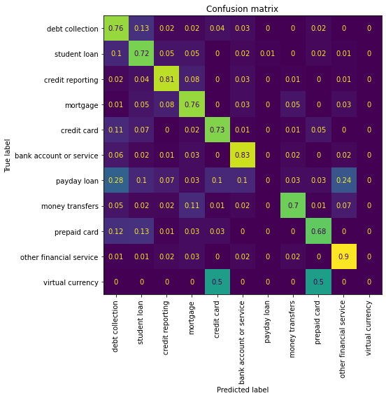

## **8 |** **FINE-TUNE DISTILBERT**

- With the fine-tune approach, we do not use the **hidden states** as fixed features
- Instead, we train them from a given model state
- This requires the **classification head** to be differentiable (neural network for classification)

### **LOAD PRETRAINED MODEL**

- We'll load the same **DistilBERT** model using `model_ckpt` **"distilbert-base-uncased"**
- This time however we will be loading `AutoModelForSequenceClassification` (we used `AutoModel` when we extracted embedding features)
- `AutoModelForSequenceClassification` model has a **classification head** on top of the pretrained model outputs
- We only need to specify the **number of labels** the model has to predict `num_labels`

```python
# Empty cache
torch.cuda.empty_cache()
```

# Empty cache torch.cuda.empty_cache()

```python
# Change Data to Torch tensor
corpus_tokenised.set_format("torch",
                            columns=["input_ids", "attention_mask", "label"])
corpus_tokenised
```

# Change Data to Torch tensor corpus_tokenised.set_format("torch", columns=["input_ids", "attention_mask", "label"]) corpus_tokenised

```
DatasetDict({
    train: Dataset({
        features: ['text', 'label', '__index_level_0__', 'input_ids', 'attention_mask'],
        num_rows: 26100
    })
    validation: Dataset({
        features: ['text', 'label', '__index_level_0__', 'input_ids', 'attention_mask'],
        num_rows: 2901
    })
})
```

```python
from transformers import AutoModelForSequenceClassification
import torch

device = torch.device("cuda" if torch.cuda.is_available() else "cpu")
model_ckpt = "distilbert-base-uncased"

model = (AutoModelForSequenceClassification
         .from_pretrained(model_ckpt,
                          num_labels=len(labels))
         .to(device))
```

from transformers import AutoModelForSequenceClassification import torch device = torch.device("cuda" if torch.cuda.is_available() else "cpu") model_ckpt = "distilbert-base-uncased" model = (AutoModelForSequenceClassification .from_pretrained(model_ckpt, num_labels=len(labels)) .to(device))

### **EVALUATION METRICS**

We'll monitor the `F1 score` & `accuracy`, the function is required to be passed in the `Trainer` class

```python
from sklearn.metrics import accuracy_score, f1_score

def compute_metrics(pred):
    labels = pred.label_ids
    preds = pred.predictions.argmax(-1)
    f1 = f1_score(labels, preds, average="weighted")
    acc = accuracy_score(labels, preds)
    return {"accuracy": acc, "f1": f1}
```

from sklearn.metrics import accuracy_score, f1_score def compute_metrics(pred): labels = pred.label_ids preds = pred.predictions.argmax(-1) f1 = f1_score(labels, preds, average="weighted") acc = accuracy_score(labels, preds) return {"accuracy": acc, "f1": f1}

### **DEFINE TRAINER**

```python
from transformers import Trainer, TrainingArguments
from transformers import Trainer

bs = 16 # batch size
model_name = f"{model_ckpt}-finetuned-financial"
labels = corpus_tokenised["train"].features["label"].names

# Training Arguments
training_args = TrainingArguments(output_dir=model_name,
                                  num_train_epochs=3,             # number of training epochs
                                  learning_rate=2e-5,             # model learning rate
                                  per_device_train_batch_size=bs, # batch size
                                  per_device_eval_batch_size=bs,  # batch size
                                  weight_decay=0.01,
                                  evaluation_strategy="epoch",
                                  disable_tqdm=False,
                                  report_to="none",
                                  push_to_hub=False,
                                  log_level="error")


trainer = Trainer(model=model,                                 # Model
                  args=training_args,                          # Training arguments (above)
                  compute_metrics=compute_metrics,             # Computational Metrics
                  train_dataset=corpus_tokenised["train"],     # Training Dataset
                  eval_dataset=corpus_tokenised["validation"], # Evaluation Dataset
                  tokenizer=tokenizer)
```

from transformers import Trainer, TrainingArguments from transformers import Trainer bs = 16 # batch size model_name = f"{model_ckpt}-finetuned-financial" labels = corpus_tokenised["train"].features["label"].names # Training Arguments training_args = TrainingArguments(output_dir=model_name, num_train_epochs=3, # number of training epochs learning_rate=2e-5, # model learning rate per_device_train_batch_size=bs, # batch size per_device_eval_batch_size=bs, # batch size weight_decay=0.01, evaluation_strategy="epoch", disable_tqdm=False, report_to="none", push_to_hub=False, log_level="error") trainer = Trainer(model=model, # Model args=training_args, # Training arguments (above) compute_metrics=compute_metrics, # Computational Metrics train_dataset=corpus_tokenised["train"], # Training Dataset eval_dataset=corpus_tokenised["validation"], # Evaluation Dataset tokenizer=tokenizer)

### **TRAIN MODEL**

Let's finally fine-tune our transform model to fit our classification problem

```python
%%time

# Train & save model
trainer.train()
trainer.save_model()
```

%%time # Train & save model trainer.train() trainer.save_model()

[4896/4896 37:20, Epoch 3/3]

| Epoch | Training Loss | Validation Loss | Accuracy | F1 |
| --- | --- | --- | --- | --- |
| 1 | 0.535000 | 0.528666 | 0.842468 | 0.839433 |
| 2 | 0.410300 | 0.483131 | 0.858669 | 0.855979 |
| 3 | 0.312500 | 0.477747 | 0.866942 | 0.864213 |

```
CPU times: user 36min 55s, sys: 16.5 s, total: 37min 12s
Wall time: 37min 21s
```

```python
# from transformers import pipeline
# load from previously saved model
# classifier = pipeline("text-classification", model="distilbert-base-uncased-finetuned-financial")
```

# from transformers import pipeline # load from previously saved model # classifier = pipeline("text-classification", model="distilbert-base-uncased-finetuned-financial")

### **INFERENCE**

Let's utilise our fine-tuned transformer model for inference on the validation dataset

```python
# Predict on Validation Dataset
pred_output = trainer.predict(corpus_tokenised["validation"])
pred_output
```

# Predict on Validation Dataset pred_output = trainer.predict(corpus_tokenised["validation"]) pred_output

[182/182 00:26]

```
PredictionOutput(predictions=array([[ 0.4898075 , -1.1539025 , -2.4000468 , ...,  2.664791  ,
        -1.7696137 , -1.85924   ],
       [ 5.524978  ,  1.4433606 , -1.2144918 , ..., -2.0602236 ,
        -2.2785227 , -3.1501598 ],
       [-0.99464035,  1.410322  ,  5.1908035 , ..., -2.1883903 ,
        -1.5084958 , -3.9436107 ],
       ...,
       [ 0.8029568 ,  2.751484  , -1.0246688 , ..., -2.6813054 ,
         0.32632264, -3.8141603 ],
       [ 0.27522528, -1.2025931 , -0.14139701, ..., -2.684458  ,
        -1.0188793 , -3.16859   ],
       [-0.17902231, -1.83018   , -0.8901656 , ..., -3.2526188 ,
         0.6185259 , -3.5121055 ]], dtype=float32), label_ids=array([4, 1, 2, ..., 0, 5, 5]), metrics={'test_loss': 0.47774738073349, 'test_accuracy': 0.8669424336435712, 'test_f1': 0.8642125632561599, 'test_runtime': 26.9558, 'test_samples_per_second': 107.621, 'test_steps_per_second': 6.752})
```

```python
print(f'Output Predition: {pred_output.predictions.shape}')
print(pred_output.predictions)
```

print(f'Output Predition: {pred_output.predictions.shape}') print(pred_output.predictions)

```
Output Predition: (2901, 11)
[[ 0.4898075  -1.1539025  -2.4000468  ...  2.664791   -1.7696137
  -1.85924   ]
 [ 5.524978    1.4433606  -1.2144918  ... -2.0602236  -2.2785227
  -3.1501598 ]
 [-0.99464035  1.410322    5.1908035  ... -2.1883903  -1.5084958
  -3.9436107 ]
 ...
 [ 0.8029568   2.751484   -1.0246688  ... -2.6813054   0.32632264
  -3.8141603 ]
 [ 0.27522528 -1.2025931  -0.14139701 ... -2.684458   -1.0188793
  -3.16859   ]
 [-0.17902231 -1.83018    -0.8901656  ... -3.2526188   0.6185259
  -3.5121055 ]]
```

```python
import numpy as np

# Decode the predictions greedily using argmax (highest value of all classes)
y_preds = np.argmax(pred_output.predictions,axis=1)
print(f'Output Prediction:{y_preds.shape}')
print(f'Predictions: {y_preds}')
```

import numpy as np # Decode the predictions greedily using argmax (highest value of all classes) y_preds = np.argmax(pred_output.predictions,axis=1) print(f'Output Prediction:{y_preds.shape}') print(f'Predictions: {y_preds}')

```
Output Prediction:(2901,)
Predictions: [4 0 2 ... 1 5 5]
```

```python
# Validation
plot_confusion_matrix(y_preds,y_valid,labels)
```

# Validation plot_confusion_matrix(y_preds,y_valid,labels)

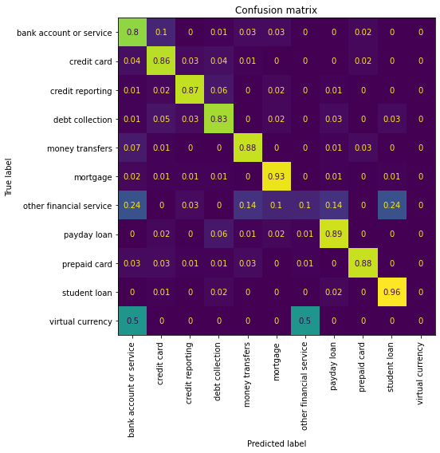

- Fine-tuning a pretrained-transformed works sufficiently better than our baseline approach
- **virtual currency** is also not predicted very well (same as the linear model)
- **payday loan** is predicted well but **other financial services** poorly